# Forest Phenology Data Analysis Report

Nasrin Farokhi

2025-06-28

# [*Question 1: Comparing ANPP in Managed vs. Unmanaged Forests*]

## **Objective**

This analysis aims to determine whether forest management has a statistically significant impact on forest productivity, as measured by Annual Net Primary Production (ANPP). To do this, we used a non-parametric statistical approach to compare log-transformed ANPP values between managed (M) and unmanaged (N) forest sites.

## **Step 1: Load Required Libraries**

We first load the packages needed for data manipulation, visualization, and reading Excel files.

```r
# Load libraries
library(readxl)
library(dplyr)
library(tidyverse)
library(ggplot2)
library(tidyr)
library(tibble)
```

```r
# Set working directory to your project folder
setwd("G:/دوره نرم افزار جنگل 2023/ProjectForest/Tree_Phenology_Project")
```

## **Step 2: Data Preparation and Filtering**

The research team imported the dataset from the ‘annual_production’ sheet and filtered it to retain only forest sites (i.e., BIOME_TYPE == ‘F’). The research team excluded sites with missing ANPP values from the analysis. The ANPP column was converted from a character to a numeric format to ensure compatibility with statistical functions. The research team applied a natural logarithm transformation `log` ANPP to the ANPP variable to improve data normality and stabilise variance across groups.

```r
# Read the "annual_production" sheet from Excel file
data <- read_excel("file_task.xlsx", sheet = "annual_production")
```

```r
# View first rows of data
head(data)
```

```
## # A tibble: 6 × 7
##   SITE_NUMBER LATITUDE LONGITUDE ANPP   BIOME_TYPE MANAGEMENT ANNUAL_TEMPERATURE
##         <dbl>    <dbl>     <dbl> <chr>  <chr>      <chr>                   <dbl>
## 1           1    -31.6     -64.8 373.5  G          N                         8.1
## 2           2    -38.2     -62.3 263.25 G          N                        12.4
## 3           3     53.2    -112.  128.6… G          N                         2.8
## 4           4     49.7    -113.  99     G          N                         6.4
## 5           5     50.7    -103.  133    G          N                         3
## 6           6     50.5    -104.  61.2   G          N                         2.4
```

```r
# Filter rows for forest biome only (BIOME_TYPE == "F")
forest_data <- data %>%
  filter(BIOME_TYPE == "F")
```

```r
# Remove rows where ANPP is missing (NA)
forest_data <- forest_data %>%
  filter(!is.na(ANPP))
```

```r
# Convert ANPP column from character to numeric
forest_data <- forest_data %>%
  mutate(ANPP = as.numeric(ANPP))
```

```r
# Remove rows where ANPP conversion produced NA
forest_data <- forest_data %>%
  filter(!is.na(ANPP))
```

```r
# Log-transform the ANPP values for normalization
forest_data <- forest_data %>%
  mutate(logANPP = log(ANPP))
```

## **Step 3: Perform Kruskal-Wallis Test**

Given the non-normal distribution of ANPP, the research team applied a `Kruskal-Wallis` rank sum test to compare the two independent groups (Managed vs. Unmanaged). Unmanaged forests). This test is a robust, non-parametric alternative to `one-way ANOVA`.

```r
# Perform Kruskal-Wallis test on logANPP by MANAGEMENT (M vs N)
kruskal_test <- kruskal.test(logANPP ~ MANAGEMENT, data = forest_data)
print(kruskal_test)
```

```
##
##  Kruskal-Wallis rank sum test
##
## data:  logANPP by MANAGEMENT
## Kruskal-Wallis chi-squared = 3.8058, df = 1, p-value = 0.05107
```

## **Results**

- Managed forests (M): 62 sites

- Unmanaged forests (N): 98 sites

- Kruskal-Wallis statistic (χ²): 3.81

- Degrees of freedom (df): 1

- p-value: 0.051

## **Interpretation**

At the conventional significance level of α = 0.05, the p-value of 0.051 is slightly above the threshold, indicating no statistically significant difference in logANPP between the two groups. However, the result is marginal and suggests a possible trend that may become significant with a larger dataset or additional control for covariates.

## **Step 4: Descriptive Statistics**

```r
# Summary statistics of logANPP per management type
forest_data %>%
  group_by(MANAGEMENT) %>%
  summarise(
    count = n(),
    median_logANPP = median(logANPP),
    IQR_logANPP = IQR(logANPP),
    min = min(logANPP),
    max = max(logANPP)
  )
```

```
## # A tibble: 2 × 6
##   MANAGEMENT count median_logANPP IQR_logANPP   min   max
##   <chr>      <int>          <dbl>       <dbl> <dbl> <dbl>
## 1 M             62           6.42       0.617  4.76  7.62
## 2 N             98           6.30       0.851  4.12  7.36
```

The median logANPP was slightly higher in managed forests, and the interquartile range (IQR) was narrower, indicating more consistent productivity among managed sites.

## **Step 5: Visualize with Boxplot**

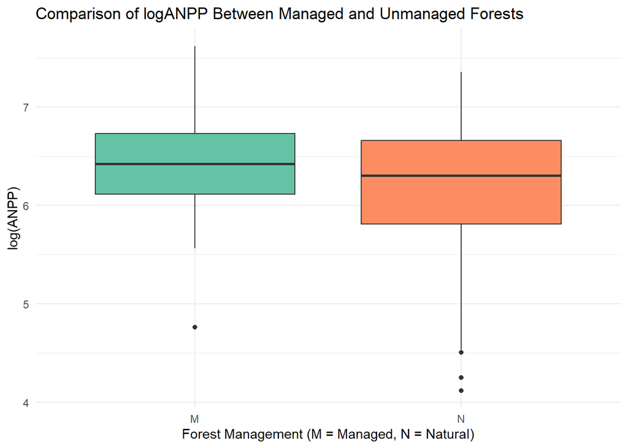

```r
# Create and store a boxplot comparing logANPP between management types

p <- ggplot(forest_data, aes(x = MANAGEMENT, y = logANPP, fill = MANAGEMENT)) +
  geom_boxplot() +
  labs(
    title = "Comparison of logANPP Between Managed and Unmanaged Forests",
    x = "Forest Management (M = Managed, N = Natural)",
    y = "log(ANPP)"
  ) +
  theme_minimal() +
  scale_fill_manual(values = c("M" = "#66C2A5", "N" = "#FC8D62")) +
  theme(legend.position = "none")
print(p)
```

The research team generated a boxplot to visually compare the distribution of logANPP between the two forest management groups. The figure illustrates a modest difference in central tendency and spread between groups, consistent with the statistical results.

```r
# Save the plot as high-resolution PNG
ggsave("logANPP_boxplot.png", plot = p, width = 8, height = 5, dpi = 300)
```

## **Conclusion**

While the `Kruskal-Wallis` test did not yield a statistically significant result at p < 0.05, the analysis indicates a potential effect of forest management on productivity. Managed forests may exhibit slightly higher and more stable above-ground net primary productivity (ANPP) levels. To validate this trend, we recommend further investigations with larger datasets, the inclusion of environmental covariates (e.g., temperature, soil type), and the use of multivariate statistical approaches.

# *Question 2: Mapping European Forest Sites: Managed vs. Unmanaged*

## **Step 1: Load Map Libraries**

```r
library(sf)
library(rnaturalearth)
library(rnaturalearthdata)
```

## **Objective**

The goal of this analysis was to visualize the spatial distribution of forest research sites across Europe and to distinguish visually between managed and unmanaged forests using map-based representation. This task aimed to combine spatial filtering, geospatial data transformation, and professional-level cartographic visualization.

## **Step 2: Data Preparation and Filtering**

The research team first filtered the dataset from the ‘annual_production’ sheet to retain only forest sites (BIOME_TYPE == ‘F’). To focus the analysis on Europe, the team used geographic coordinates to extract the relevant subset.  
- Latitude between 35° and 70° N

- Longitude between −25° and 40° E

```r
# Filter forest sites located in European lat/lon ranges
europe_data <- forest_data %>%
  filter(LATITUDE >= 35, LATITUDE <= 70,
         LONGITUDE >= -25, LONGITUDE <= 40)
```

## **Step 3: Basic Scatter Map (Exploratory Visualization)**

The research team created an initial exploratory plot using ggplot2, mapping longitude versus latitude and applying colour codes to differentiate sites by management status.

- Green: Managed forests (M)

- Blue: Unmanaged forests (N)

The map allowed us to efficiently validate the spatial filtering and confirm the correct geographic location of all sites within Europe.

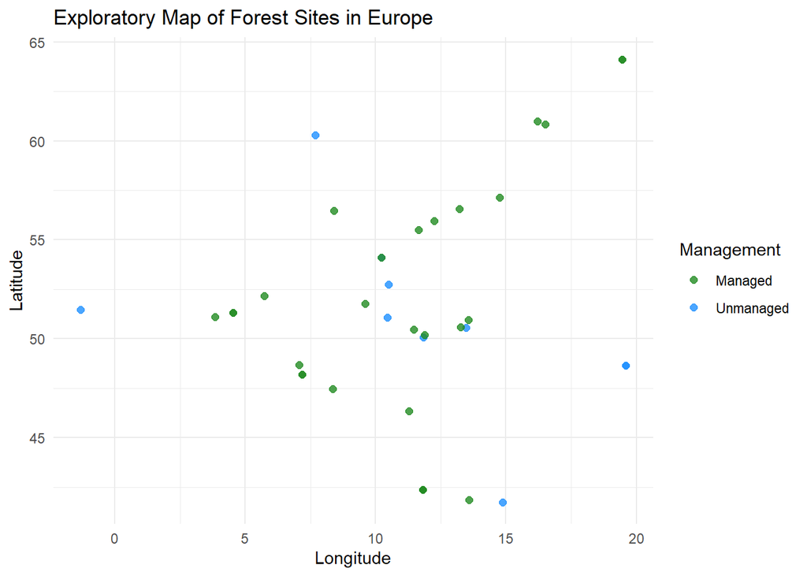

```r
# Simple scatter map without a basemap
ggplot(europe_data, aes(x = LONGITUDE, y = LATITUDE, color = MANAGEMENT)) +
  geom_point(size = 2, alpha = 0.8) +
  scale_color_manual(
    values = c("M" = "forestgreen", "N" = "dodgerblue"),
    labels = c("Managed", "Unmanaged")
  ) +
  labs(
    title = "Exploratory Map of Forest Sites in Europe",
    x = "Longitude",
    y = "Latitude",
    color = "Management"
  ) +
  theme_minimal()
```